# MS4S09 - Amazon Book Reviews

Moses Owhonda

# INTRODUCTION

> In today’s digital age, online reviews play a significant role in shaping consumer decisions, particularly in the realm of book purchases. Understanding reading sentiments, preferences, and patterns hidden within these reviews can provide invaluable insights for publishers, authors, and potential readers alike.

> In this project, we aim to dive deep into an Amazon book reviews dataset, leveraging various analytical techniques to extract meaningful insights. The dataset comprises book reviews written by customers on *Amazon*, encompassing various features that can aid our analysis. Each row in the dataset represents a single review, with the primary focus being on the `Review_text` feature. Our primary goal is to analyze reviews and uncover general trends and patterns of readers’ feedback. Our tasks include -
- Utilize pre-processing and text mining techniques to prepare and draw insights from the provided text data, accompanied by informative visualizations.
- Employ sentiment analysis techniques to understand and classify review sentiments, allowing us to gauge reader satisfaction levels.
- Implement topic modeling techniques to cluster reviews and identify hidden trends within the text, providing a structured overview of review segmentation.
- Utilize exploratory data analysis to derive meaningful insights from the text, leveraging all available variables within the dataset.

#### Features Description:

`Title`: *The title of the book.*

`Book_Price`: *The price of the book.*

`Reviewer_id`: *The ID of the user who rated the book.*

`Rating`: *The rating given by the reviewer (ranging from 1 to 5).*

`Time`: *Time of the review, converted to seconds from a reference start date.*

`Review_title`: *The title or summary of the review.*

`Review_text`: *The full text of the review.*

`Found_helpful_ratio`: *Helpfulness rating of the review, voted by other users.*

`Publisher`: *Name of the publisher of the book.*

`First_author`: *The author of the book, or the first listed author if multiple.*

`Genre`: *The genre of the book.*

#### Load in necessary libraries

```r
libraries <- c("tm", "text", "tidytext", "ggplot2", "wordcloud", "syuzhet", "dplyr", "tibble", "textstem", "textdata", "tidyr", "Matrix", "topicmodels", "stringr", "reshape2", "LDAvis", "jsonlite", "quanteda", "textTinyR", "broom", "gridExtra")


 # Library takes function names without quotes, character only must be used in a loop of this kind.
for (lib in libraries) {
  library(lib, character.only=TRUE)
}
```

#### Load Dataset

```r
# Define file path
filepath <- 'C:\\Users\\HP\\Documents\\USW\\Courses\\Data Mining R\\MS4S09_CW_Book_Reviews.csv'
df_main <- as_tibble(read.csv(filepath, stringsAsFactors = FALSE)) # Since we have text data we do not want this read as a factor


# Inspect summary and first five rows of data
print(summary(df_main))
```

```
##     Title             Book_Price     Reviewer_id            Rating
##  Length:59296       Min.   :  1.00   Length:59296       Min.   :1.000
##  Class :character   1st Qu.: 10.36   Class :character   1st Qu.:4.000
##  Mode  :character   Median : 14.15   Mode  :character   Median :5.000
##                     Mean   : 20.81                      Mean   :4.231
##                     3rd Qu.: 22.99                      3rd Qu.:5.000
##                     Max.   :995.00                      Max.   :5.000
##       Time           Review_title       Review_text        Found_helpful_ratio
##  Min.   :8.688e+08   Length:59296       Length:59296       Min.   :0.0000
##  1st Qu.:1.087e+09   Class :character   Class :character   1st Qu.:0.0000
##  Median :1.169e+09   Mode  :character   Mode  :character   Median :0.6667
##  Mean   :1.173e+09                                         Mean   :0.5491
##  3rd Qu.:1.279e+09                                         3rd Qu.:1.0000
##  Max.   :1.362e+09                                         Max.   :1.0000
##   Publisher         First_author          Genre
##  Length:59296       Length:59296       Length:59296
##  Class :character   Class :character   Class :character
##  Mode  :character   Mode  :character   Mode  :character
##
##
##
```

```r
print(head(df_main))
```

```
## # A tibble: 6 × 11
##   Title            Book_Price Reviewer_id Rating   Time Review_title Review_text
##   <chr>                 <dbl> <chr>        <int>  <int> <chr>        <chr>
## 1 In Six Days: Wh…      10.2  APD7XINUVG…      4 9.99e8 Solid testi… "Working f…
## 2 Lord Jim              15.6  AITANZIKX8…      5 9.16e8 &quot;You d… "A terrifi…
## 3 White Socks Only       5.16 AYB19RB36G…      4 1.34e9 White Socks… "As I open…
## 4 The Secret of t…      15.0  A1BOLCK0Q5…      5 1.28e9 great!       "Excellent…
## 5 Left to Tell: D…      17.5  A3WKJ88K78…      5 1.36e9 Great Book   "This book…
## 6 Don't Make Me T…      20.9  A1E6I4IPWW…      5 1.20e9 Don't think… "Excellent…
## # ℹ 4 more variables: Found_helpful_ratio <dbl>, Publisher <chr>,
## #   First_author <chr>, Genre <chr>
```

```r
# Confirm there are no null values in any of the columns
print(colSums(is.na(df_main)))
```

```
##               Title          Book_Price         Reviewer_id              Rating
##                   0                   0                   0                   0
##                Time        Review_title         Review_text Found_helpful_ratio
##                   0                   0                   0                   0
##           Publisher        First_author               Genre
##                   0                   0                   0
```

# TEXT MINING

Text mining is an analysis technique that involves extracting valuable insights and patterns from unstructured text data. It encompasses various tasks which ultimately enables us to uncover hidden information, sentiments, and trends within textual data, aiding in understanding user preferences, and gaining valuable insights from large volumes of text.

#### Select relevant columns

```r
# Create an ID column
df_main$id <- 1:nrow(df_main)

# Reorder the columns to move the ID column to the first position
df_main <- df_main %>%
  select(id, everything())

df <- df_main # Copy dataframe

df <- df[,c(1,2,5,7,8)] # Select relevant columns
print(tail(df))
```

```
## # A tibble: 6 × 5
##      id Title                                    Rating Review_title Review_text
##   <int> <chr>                                     <int> <chr>        <chr>
## 1 59291 Charms And Charm Bracelets: The Complet…      5 Charms       This is an…
## 2 59292 Anne of the Island                            5 times revis… I was lost…
## 3 59293 Manga Mania Shoujo: How to Draw the Cha…      4 Cool and he… I saw this…
## 4 59294 Tales from Kalila Wa Dimna: For Student…      4 Good storie… This is a …
## 5 59295 Brain Teasers                                 2 Mediocre pu… This puzzl…
## 6 59296 Left to Tell: Discovering God Amidst Th…      5 Wonderful b… Was a wond…
```

#### Create Tokens

```r
# Tokenize review column by word
word_tokenized_data <- df %>%
  unnest_tokens(output = word, input = "Review_text", token = "words", to_lower = TRUE)

bigram_tokenized_data <- df %>%
  unnest_tokens(output = bigram, input = "Review_text", token = "ngrams", n=2, to_lower = TRUE)
```

Tokenization is a crucial step in natural language processing tasks, including text mining and sentiment analysis. By breaking down textual data into smaller units, such as words or n-grams (in this case, bigrams), tokenization helps in extracting meaningful insights from text data. These tokens serve as the building blocks for various analytical techniques, enabling efficient processing and analysis of textual information.

#### Visualizations before cleaning

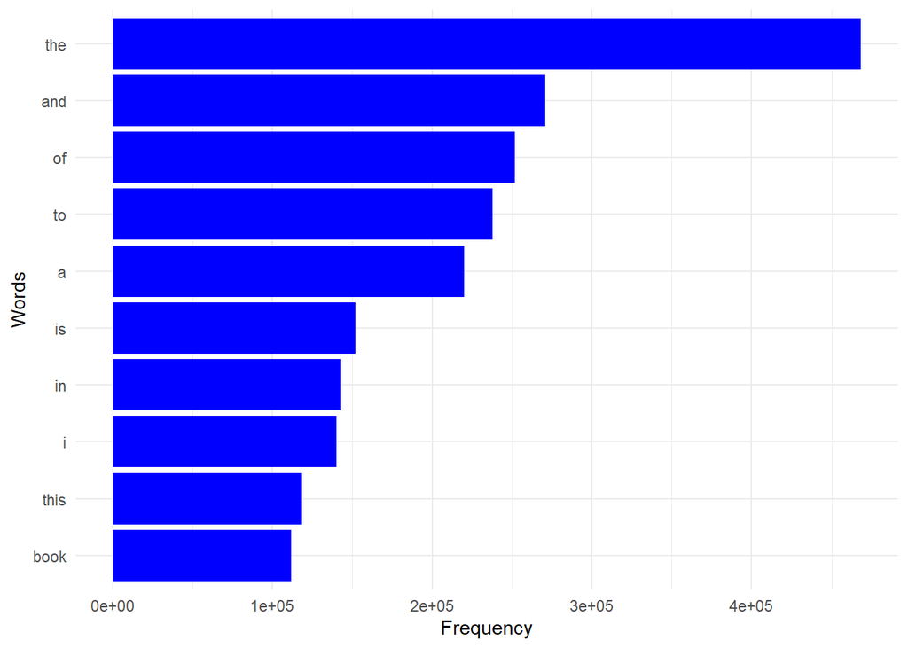

```r
#Words Visualisation
word_counts <- word_tokenized_data %>%
  count(word, sort = TRUE) # Counts the occurences of each word and sorts.

ggplot(word_counts[1:10, ], aes(x = reorder(word, n), y = n)) + # Plots first 10 rows of word counts, with word (ordered by n) on the x axis and n on the y axis
  geom_col(fill = "blue") + # Sets colours of bars to blue
  labs(x = "Words", y = "Frequency") + # Defines x and y labels
  coord_flip() + # Flips coordinates so words go on the y axis (for readability)
  theme_minimal() # Sets theme of visualisation
```

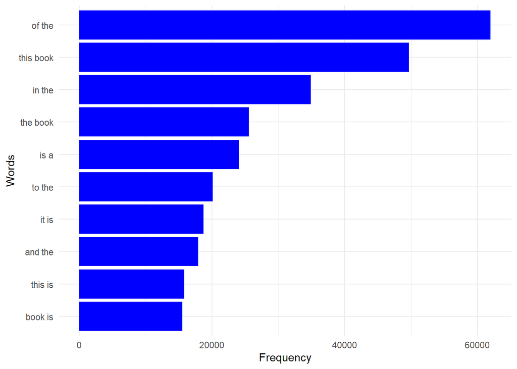

```r
# Bigram Visualization
bigram_counts <- bigram_tokenized_data %>%
  count(bigram, sort = TRUE) # Counts the occurences of each word and sorts.

ggplot(bigram_counts[1:10, ], aes(x = reorder(bigram, n), y = n)) + # Plots first 10 rows of bigram counts, with bigram (ordered by n) on the x axis and n on the y axis
  geom_col(fill = "blue") + # Sets colours of bars to blue
  labs(x = "Words", y = "Frequency") + # Defines x and y labels
  coord_flip() + # Flips coordinates so words go on the y axis (for readability)
  theme_minimal() # Sets theme of visualisation
```

The plots illustrate the frequency of the most common words and bigrams in the dataset. These words are typical English terms, commonly known as “stop words,” which do not convey significant meaning in the context of our analysis. Thus, we will conduct preprocessing procedures to remove these stopwords.

#### Data cleaning for words

```r
clean_tokens <- word_tokenized_data %>%
  anti_join(stop_words, by = "word") # Removes stop words

clean_tokens$word <- gsub("[^a-zA-Z ]", "", clean_tokens$word) %>% # Remove special characters and numbers
  na_if("") %>% # Replaces empty strings with NA
  lemmatize_words() # Lemmatizes text

clean_tokens <- na.omit(clean_tokens) # Removes null values
```

#### Data Cleaning for bigrams

```r
clean_text <- Corpus(VectorSource(df$Review_text))

# Preprocess the text
clean_text <- tm_map(clean_text, content_transformer(tolower)) %>%
  tm_map(content_transformer(function(x) gsub("[^a-zA-Z ]", "", x))) %>%
  tm_map(removeWords, stopwords("english"))
# Convert the corpus to a tidy dataframe with one row per word
df_text <- data.frame(text = sapply(clean_text, function(x) paste(unlist(strsplit(as.character(x), " ")), collapse=" ")))


df_text <- df_text %>%
  mutate(text = ifelse(text == "", NA, text)) %>%
  lemmatize_words() #lemmatize text

df_text <- na.omit(df_text) # Removes null values

# Generate bigrams using unnest_tokens
bigrams_clean_tokens <- df_text %>%
  unnest_tokens(output=bigram, input="text", token = "ngrams", n=2, to_lower = TRUE)
```

#### Visualizations after cleaning

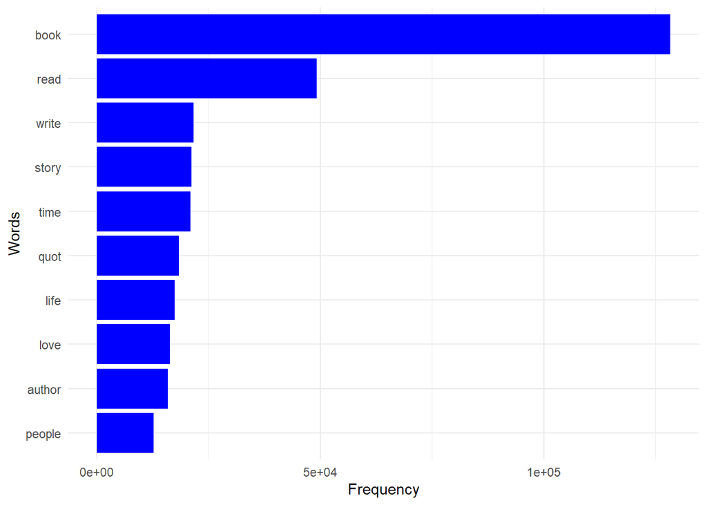

```r
word_counts <- clean_tokens %>%
  count(word, sort = TRUE)

top_words <- top_n(word_counts,10,n)$word

filtered_word_counts <- filter(word_counts, word %in% top_words)
filtered_word_counts$word <- factor(filtered_word_counts$word, levels = top_words[length(top_words):1])

ggplot(filtered_word_counts, aes(x = reorder(word, n), y = n)) +
  geom_col(fill = "blue") +
  labs(x = "Words", y = "Frequency") +
  coord_flip() +
  theme_minimal()
```

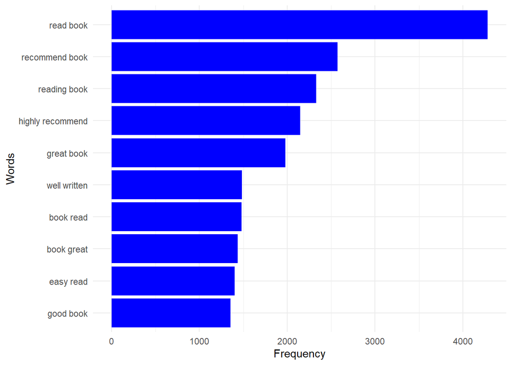

```r
#Bigram Visualization
bigram_counts <- bigrams_clean_tokens %>%
  count(bigram, sort = TRUE) # Counts the occurences of each word and sorts.

ggplot(bigram_counts[1:10, ], aes(x = reorder(bigram, n), y = n)) + # Plots first 10 rows of word counts, with word (ordered by n) on the x axis and n on the y axis
  geom_col(fill = "blue") + # Sets colours of bars to blue
  labs(x = "Words", y = "Frequency") + # Defines x and y labels
  coord_flip() + # Flips coordinates so words go on the y axis (for readability)
  theme_minimal() # Sets theme of visualisation
```

Compared to the previous plots, which depicted the frequency of stopwords, these plots, after cleaning, display the frequency of more specific, content-related words. This offers deeper insight into the specific content of the text, rather than merely focusing on common words. For example, the word *book* has the highest frequency, occurring over 100,000 times, followed by *read* with a significantly lower frequency. All other words have frequencies under 50,000 occurrences. This indicates that the words *book* and *read* are prominent topics in the text.

#### Create Word Cloud

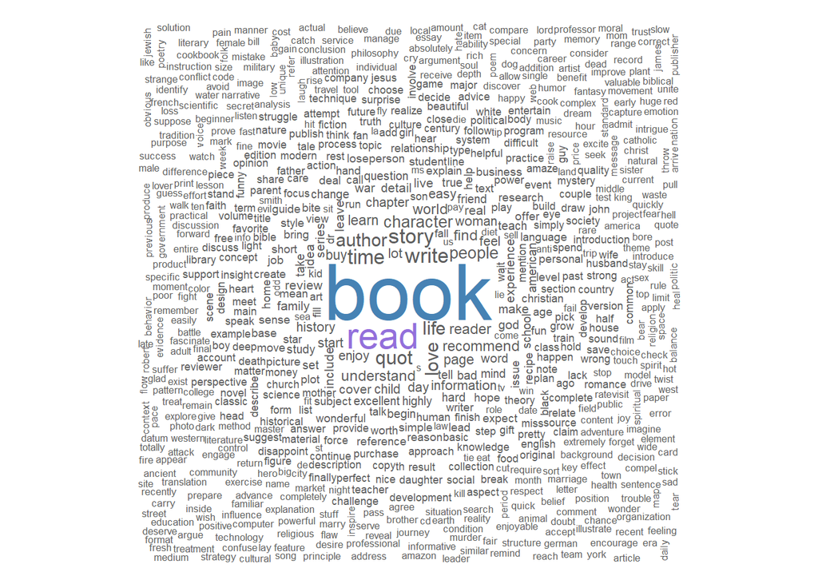

```r
set.seed(7)
# Plot word cloud
suppressWarnings( # Suppress warnings about unplotted words
  wordcloud(
    words = word_counts$word,
    freq = word_counts$n,
    min.freq = 200, # Adjust the minimum frequency threshold
    max.words = 1000, # Set maximum words to plot
    random.order = FALSE,
    random.color = FALSE,
    colors = sample(colors(), size = 5)
  )
)
```

In the word cloud visualization, words are depicted in various sizes to represent their prominence or frequency. A notable observation from our analysis is the central and largest word, **book**, which signifies the primary theme of the word cloud. Surrounding **book**, we find smaller words closely related to reading and writing, such as **story**, **character**, **author**, and **publish**.

# SENTIMENT ANALYSIS

Sentiment analysis is a technique used to analyze and quantify the sentiment or emotional tone expressed in text data. It involves identifying and categorizing the polarity of opinions, attitudes, or emotions conveyed within textual content, typically as positive, negative, or neutral. For our sentiment analysis, we will explore the bing and afinn sentiment lexicons.

```r
# Create dataset containing only words with associated sentiment & adds sentiment column.

sentiment_bing <- clean_tokens %>%
  inner_join(get_sentiments("bing"), by = "word", relationship="many-to-many") # Joins lexicon to dataset using only words that are in both.

sentiment_afinn <- clean_tokens %>%
  inner_join(get_sentiments("afinn"), by = "word")


# Calculate sentiment scores for each review
score_bing <- sentiment_bing %>%
  group_by(id) %>%
  summarize(bing_sentiment = sum(sentiment == "positive") - sum(sentiment == "negative")) # Calculates sentiment score as sum of number of positive and negative sentiments

score_afinn <- sentiment_afinn %>%
  group_by(id) %>%
  summarize(afinn_sentiment = sum(value))

# Merge scores with dataframe
df_sentiment <- df %>%
  inner_join(score_bing, by = "id") %>%
  inner_join(score_afinn, by = "id")

# Preview sentiments data
head(df_sentiment, 10)
```

```
## # A tibble: 10 × 7
##       id Title    Rating Review_title Review_text bing_sentiment afinn_sentiment
##    <int> <chr>     <int> <chr>        <chr>                <int>           <dbl>
##  1     1 In Six …      4 Solid testi… "Working f…              1               6
##  2     2 Lord Jim      5 &quot;You d… "A terrifi…              1               4
##  3     3 White S…      4 White Socks… "As I open…              0               1
##  4     4 The Sec…      5 great!       "Excellent…              3               8
##  5     5 Left to…      5 Great Book   "This book…              2               6
##  6     6 Don't M…      5 Don't think… "Excellent…              0               2
##  7     7 Eldest …      5 A good book… "I've neve…              1               2
##  8     8 Search …      5 Finally! An… "Many peop…              0               2
##  9     9 Getting…      5 Excellent f… "This is t…              1               1
## 10    10 Life is…      5 It's sad, i… "I love th…              1               3
```

The bing lexicon assigns sentiment scores based on word associations, while the AFINN lexicon provides numerical scores for polarity. Positive scores denote positive sentiment, while negative scores indicate negativity.

The resulting data from the analysis includes sentiment scores from both lexicons, categorized into broader labels such as **Positive** or **Negative**.

#### Inspection of Sentiment Analysis

```r
# Print best reviews for both sentiments
best_bing <- df_sentiment[order(df_sentiment$bing_sentiment, decreasing = TRUE)[1],"Review_text"]
best_afinn <- df_sentiment[order(df_sentiment$afinn_sentiment, decreasing = T)[1],"Review_text"]

for (review in best_bing){
  print(review)
}
```

```
## [1] "This volume includes the work of some of the leading figures in the science and religion love dialogue. The essays are the product of a conference entitled \"Empathy, Altruism and Agape: Perspectives on Love in Science and Religion.\" Major funding for this 1999 conference came from the John…
```

```r
for (review in best_afinn){
  print(review)
}
```

```
## [1] "[again, as no doubt will always be the case, i have to change what i have written!/eat my words]dionysius is close to the neoplatonists, though predates plotinus by two or three centuries. he believes that god is not only that from which everything proceedes and in and by which all exist/hav…
```

```r
# Print worst reviews for both sentiments
worst_bing <- df_sentiment[order(df_sentiment$bing_sentiment)[1],"Review_text"]
worst_afinn <- df_sentiment[order(df_sentiment$bing_sentiment)[1],"Review_text"]

for (review in worst_bing){
  print(review)
}
```

```
## [1] "I would really like to believe what Ben Wattenberg writes in this book \"Fewer\" about the prospects for world population. He thinks that overpopulation is no threat at all. Instead, he says that depopulation is our only cause for concern. But he isn't very persuasive, and seems to repeatedl…
```

```r
for (review in worst_afinn){
  print(review)
}
```

```
## [1] "I would really like to believe what Ben Wattenberg writes in this book \"Fewer\" about the prospects for world population. He thinks that overpopulation is no threat at all. Instead, he says that depopulation is our only cause for concern. But he isn't very persuasive, and seems to repeatedl…
```

#### Distribution of Sentiment Analysis

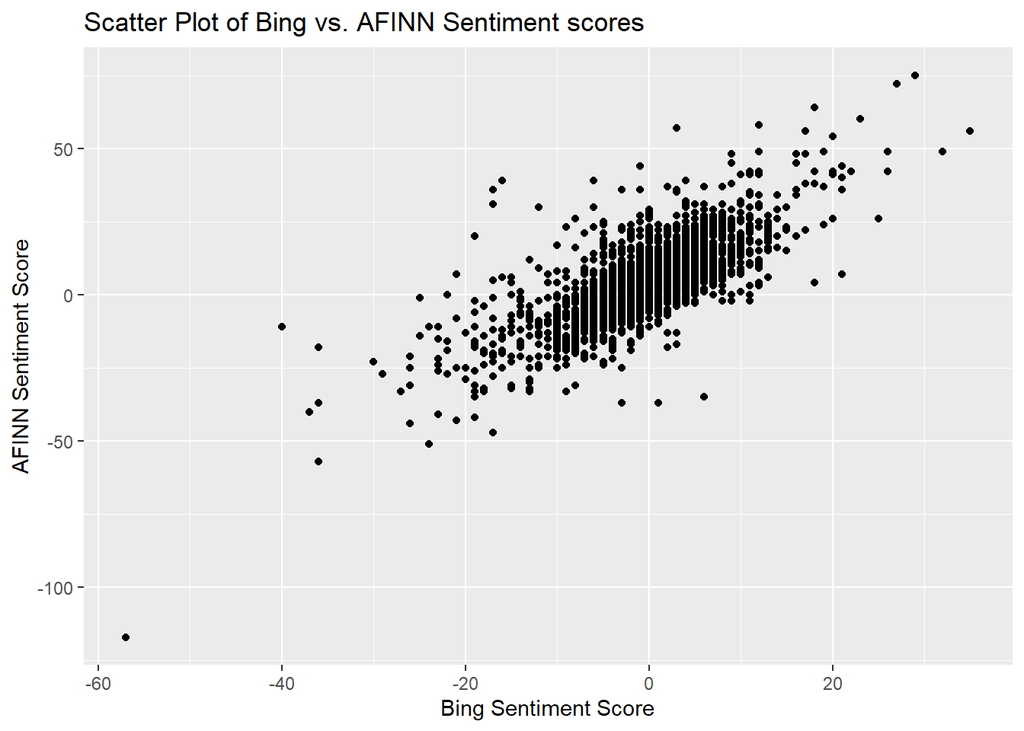

```r
# Scatter Plot of Bing vs. AFINN Sentiment scores

df_subset <- df_sentiment %>% sample_frac(0.1)  # for a sample fraction of the data

ggplot(df_subset, aes(x = bing_sentiment, y = afinn_sentiment)) +
  geom_point() +
  labs(title = "Scatter Plot of Bing vs. AFINN Sentiment scores",
       x = "Bing Sentiment Score",
       y = "AFINN Sentiment Score")
```

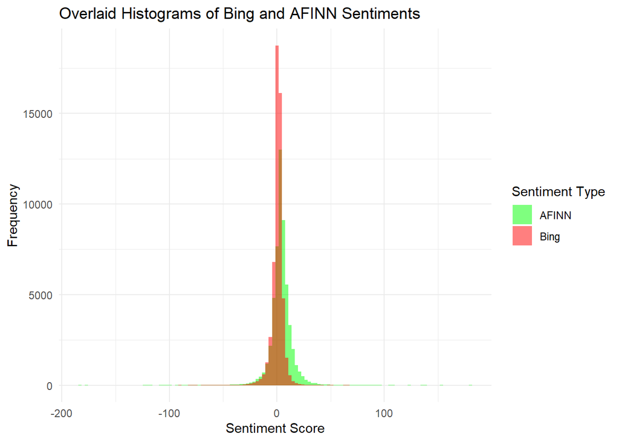

```r
# Histograms of Bing vs. AFINN Sentiment scores
df_plot <- rbind(
  data.frame(sentiment = df_sentiment$bing_sentiment, type = "Bing"),
  data.frame(sentiment = df_sentiment$afinn_sentiment, type = "AFINN") # Create a new dataframe for plotting
)

ggplot(df_plot, aes(x = sentiment, fill = type)) +
  geom_histogram(binwidth = 3, alpha = 0.5, position = "identity") +
  labs(x = "Sentiment Score", y = "Frequency", fill = "Sentiment Type",
       title = "Overlaid Histograms of Bing and AFINN Sentiments") +
  theme_minimal() +
  scale_fill_manual(values = c("green", "red"))
```

The scatter plot shows a positive correlation between Bing Sentiment Score and AFINN Sentiment Score. As the Bing score increases, the AFINN score also tends to increase. This indicates that both scoring systems are likely measuring similar aspects of sentiment. The dense clustering of dots forming an upward trend from the bottom left to the top right further supports this observation.

From the overlaid histograms, AFINN has a broader distribution, indicating a wider range of sentiment scores and it appears that bing sentiments have higher frequencies. Overall, both sentiment lexicons seem to have concentration of sentiment scores around 0.

#### Sentiment Analysis by category

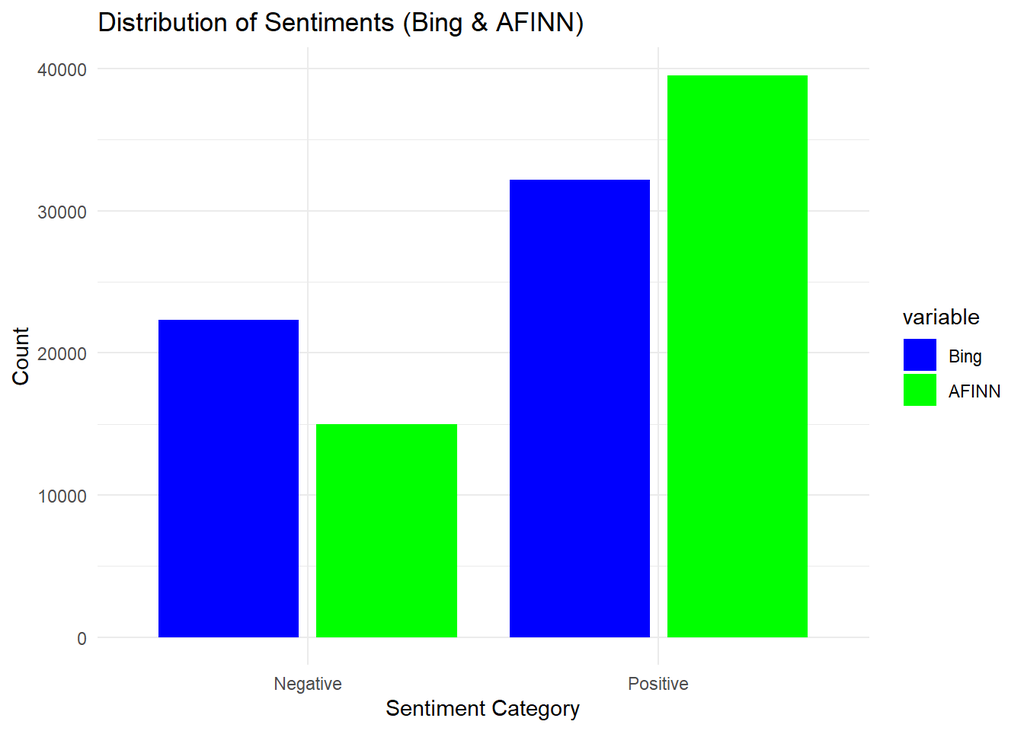

```r
# Convert sentiments to 'positive' and 'negative'
df_sentiment$bing_sentiment_category <- ifelse(df_sentiment$bing_sentiment > 0, 'Positive', 'Negative')
df_sentiment$afinn_sentiment_category <- ifelse(df_sentiment$afinn_sentiment > 0, 'Positive', 'Negative')

# Create a table of sentiment counts
bing_sentiment_counts <- table(df_sentiment$bing_sentiment_category)
afinn_sentiment_counts <- table(df_sentiment$afinn_sentiment_category)

# Convert the table to a data frame and rename the columns
bing_chart <- as.data.frame(bing_sentiment_counts)
afinn_chart <- as.data.frame(afinn_sentiment_counts)

names(bing_chart) <- c('Category', 'Count')
names(afinn_chart) <- c('Category', 'Count')

# Combine the Bing and AFINN sentiment counts data frames
combined_sentiment_counts <- merge(bing_chart, afinn_chart, by = "Category", all = TRUE)
combined_sentiment_counts <- melt(combined_sentiment_counts, id.vars = "Category") # Reshape the data

# Plot the clustered bar chart
ggplot(combined_sentiment_counts, aes(x = Category, y = value, fill = variable)) +
  geom_bar(stat = "identity", position = position_dodge(width = 0.9), width = 0.8) +
  theme_minimal() +
  ggtitle("Distribution of Sentiments (Bing & AFINN)") +
  scale_fill_manual(values = c("blue", "green"), labels = c("Bing", "AFINN")) +  # Adjust color scheme
  labs(x = "Sentiment Category", y = "Count")  # Add axis labels
```

According to both sentiment lexicons in the clustered bar chart, there are significantly more positive sentiments than negative ones in the dataset. However, it appears that AFINN has recorded a significantly higher count of positive sentiments compared to bing. Conversely, bing has a higher count of negative sentiments compared to AFINN.

# TOPIC MODELLING

Topic modeling is a technique used to discover latent thematic structures within a collection of text documents. It aims to automatically identify topics or themes that frequently co-occur in the corpus and assigns each document a distribution over these topics. We will explore *Latent Dirichlet Allocation* (LDA) to build our topic model.

*LDA is a probabilistic model that represents documents as mixtures of topics, where each topic is characterized by a distribution of words. The model assumes that documents are generated based on a probabilistic process involving a mixture of topics, and words within documents are chosen according to the distribution of topics.*

#### Data Selection

```r
tm <- df_main # Copy dataframe

# Select Columns
tm <- tm %>%
  select(c("id", "Review_title", "Review_text", "Publisher", "First_author", "Genre")) %>%
  filter(str_count(Review_text) >= 200 & str_count(Review_text) <= 500)
```

```r
# Filter to Selected Categories
genre_counts <- data.frame(table(tm$Genre))
genre_counts <- genre_counts[order(genre_counts$Freq, decreasing = T),]
genre_to_use <- c("Fiction", "Religion", "Business & Economics", "History", "Health & Fitness",
                  "Biography & Autobiography", "Family & Relationships", "Cooking", "Computers")

tm <- filter(tm, Genre %in% genre_to_use)
```

We filtered the data to include only the genres that are of interest for our topic modeling analysis. This is necessary because the original dataset contains a wide range of genres, but our focus is on a specific subset of genres deemed most relevant or frequent. By filtering the dataset to include only the selected genres, we reduce the complexity of the analysis and ensure that our topic model is tailored to the specific genres of interest. This approach enables us to focus our analysis on the most relevant genres while excluding less common or unrelated genres from the modeling process.

Next, we will create our Term-Document Matrix.

#### Creation of Term Document Matrix

```r
# Convert text column to corpus
corpus <- VCorpus(VectorSource(tm$Review_text))


# Apply preprocessing
corpus <- tm_map(corpus, content_transformer(tolower)) %>%
  tm_map(content_transformer(function(x) gsub("[^a-zA-Z ]", "", x))) %>%
  tm_map(removeWords, stopwords("english")) %>%
  tm_map(removeWords, c("book", "read")) %>%
  tm_map(content_transformer(textstem::lemmatize_strings))


# Convert to a term document matrix
tdm <- TermDocumentMatrix(corpus, control = list(wordLengths = c(4, 15)))

tdm_matrix <- as.matrix(tdm)
```

The Term-Document Matrix represents the frequency of terms (words) across documents (reviews). The text data is preprocessed to convert it to lowercase, remove punctuation, stopwords, and specific words like *book* and *read*, and perform lemmatization to reduce words to their base form. The resulting TDM will serve as input for our topic modeling, allowing us to explore patterns and insights within the corpus of reviews. Next, we will examine and select the terms for our topic model.

#### Term Selection

```r
term_frequencies <- rowSums(tdm_matrix)

# Create a data frame for plotting
term_frequency_tm <- data.frame(term = names(term_frequencies), frequency = term_frequencies)

# Sort the data frame by frequency in descending order and select the top 10
top_terms <- term_frequency_tm %>%
  arrange(desc(frequency)) %>%
  head(10)

# Display the top 10 terms
print(top_terms)
```

```
##        term frequency
## good   good      4770
## great great      2356
## story story      2206
## love   love      2024
## write write      1944
## like   like      1940
## book   book      1910
## make   make      1867
## find   find      1729
## time   time      1694
```

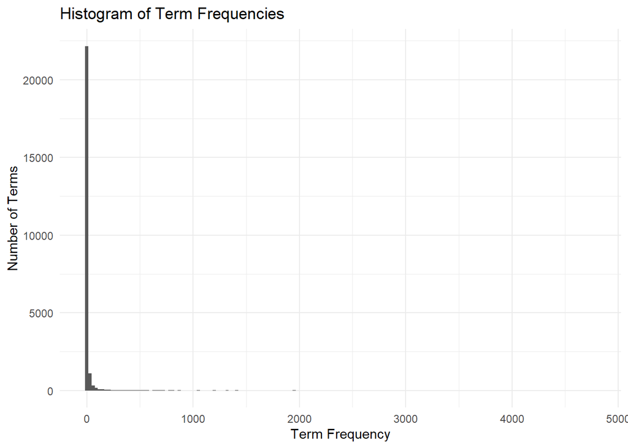

```r
# Create the histogram
ggplot(term_frequency_tm, aes(x = frequency)) +
  geom_histogram(binwidth = 30) +
  labs(title = "Histogram of Term Frequencies",
       x = "Term Frequency",
       y = "Number of Terms") +
  theme_minimal()
```

The top words in this word frequency distribution predominantly consist of common English words, which may lack informative value. To enhance the relevance of our analysis within the selected book genres, we will apply filtering techniques to remove these common but less informative words. This refinement aims to highlight words that convey richer meaning within the context of our analysis.

#### Filtering of Words

```r
# Find terms that appear in more than 10% of documents
frequent_terms <- findFreqTerms(tdm, lowfreq = 0.10 * ncol(tdm_matrix))
# Find terms that appear in less than 0.5% of documents
rare_terms <- findFreqTerms(tdm, highfreq = 0.005 * ncol(tdm_matrix))

print(frequent_terms) #Frequent Terms
```

```
##  [1] "author"    "book"      "character" "enjoy"     "find"      "first"
##  [7] "give"      "good"      "great"     "interest"  "just"      "know"
## [13] "life"      "like"      "look"      "love"      "make"      "many"
## [19] "much"      "read"      "really"    "recommend" "story"     "think"
## [25] "time"      "want"      "work"      "write"
```

```r
print(rare_terms[1:20]) #First 20 Infrequent Terms
```

```
##  [1] "aahing"       "aaliyah"      "aaliyahmore"  "aarhus"       "aasimov"
##  [6] "abandon"      "abandonment"  "abbess"       "abbott"       "abbotts"
## [11] "abbreviate"   "abbreviation" "abdominal"    "abduct"       "abel"
## [16] "abelard"      "aber"         "abhorrence"   "abide"        "abilites"
```

```r
# Edit list of frequent words to keep useful ones
to_keep <- c("love", "life") # These words could be meaningful in some of the selected genres

to_remove <- frequent_terms[!frequent_terms %in% to_keep]

filtered_tdm_matrix <- tdm_matrix[!rownames(tdm_matrix) %in% to_remove, ]
filtered_tdm_matrix <- filtered_tdm_matrix[!rownames(filtered_tdm_matrix) %in% rare_terms, ]

# Remove zero sum columns from tdm.
column_sums <- colSums(filtered_tdm_matrix) # Calculate column sums

# Identify columns that are all zeros
zero_columns <- which(column_sums == 0)

# Remove these columns
if(length(zero_columns) > 0) {
  # Remove these columns
  filtered_tdm_matrix <- filtered_tdm_matrix[, -zero_columns]
} else {
  # If no columns are all zeros, just use the original matrix
  print("No zero columns in TDM matrix")
}
```

#### Word Frequency Distribution After Filtering

```r
term_frequencies <- rowSums(filtered_tdm_matrix)

# Create a data frame for plotting
term_frequency_ <- data.frame(term = names(term_frequencies), frequency = term_frequencies)

# Sort the data frame by frequency in descending order and select the top 30
top_terms <- term_frequency_ %>%
  arrange(desc(frequency)) %>%
  head(30)

# Display the top 30 terms
print(top_terms)
```

```
##                    term frequency
## love               love      2024
## life               life      1403
## help               help       880
## year               year       877
## take               take       876
## also               also       855
## feel               feel       822
## easy               easy       811
## need               need       811
## people           people       811
## even               even       788
## understand   understand       788
## little           little       779
## anyone           anyone       768
## novel             novel       726
## page               page       716
## thing             thing       715
## come               come       709
## start             start       683
## recipe           recipe       681
## keep               keep       672
## excellent     excellent       661
## series           series       660
## information information       654
## highly           highly       644
## learn             learn       643
## must               must       642
## history         history       579
## every             every       576
## reader           reader       564
```

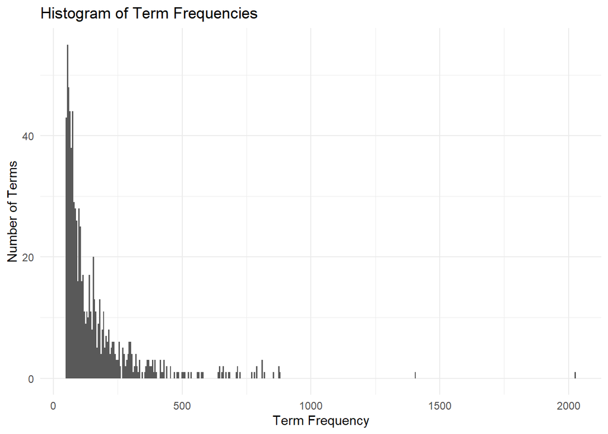

```r
# Create the histogram
ggplot(term_frequency_, aes(x = frequency)) +
  geom_histogram(binwidth = 5) +
  labs(title = "Histogram of Term Frequencies",
       x = "Term Frequency",
       y = "Number of Terms") +
  theme_minimal()
```

Following the filtering process, we observed a shift towards content-related words such as *recipe*, *love*, *year*, etc., appearing among the top terms. These terms are more likely to provide meaningful insights into the content of the books within the selected genres.

Given these results, we will proceed with further term selection to refine the terms used in our topic model. This additional refinement step aims to enhance the robustness of our analysis.

#### Additional Term Selection

```r
to_remove <- c("also", "even", "take", "little", "come", "understand", "easy", "find", "help", "feel", "thing", "need", "people", "anyone", "come", "keep", "must", "every", "start", "reader")

filtered_tdm_matrix <- filtered_tdm_matrix[!rownames(filtered_tdm_matrix) %in% to_remove, ]

term_frequencies <- rowSums(filtered_tdm_matrix)

# Create a data frame for plotting
term_frequency_df <- data.frame(term = names(term_frequencies), frequency = term_frequencies)

# Sort the data frame by frequency in descending order and select the top 10
top_terms <- term_frequency_df %>%
  arrange(desc(frequency)) %>%
  head(10)

# Display the top 10 terms
print(top_terms)
```

```
##                    term frequency
## love               love      2024
## life               life      1403
## year               year       877
## novel             novel       726
## page               page       716
## recipe           recipe       681
## excellent     excellent       661
## series           series       660
## information information       654
## highly           highly       644
```

Through additional term selection, we’ve refined our filtering process to prioritize content-related words over generic ones. With this enhanced dataset, we’re now prepared to create our topic model. This model will leverage the filtered text to extract meaningful themes and insights from the data.

#### Create LDA Model

We will utilize the *Coherence*, *Perplexity*, and *Log-likelihood* metrics to evaluate the performance of the LDA model in order to get the optimal value of *k*.

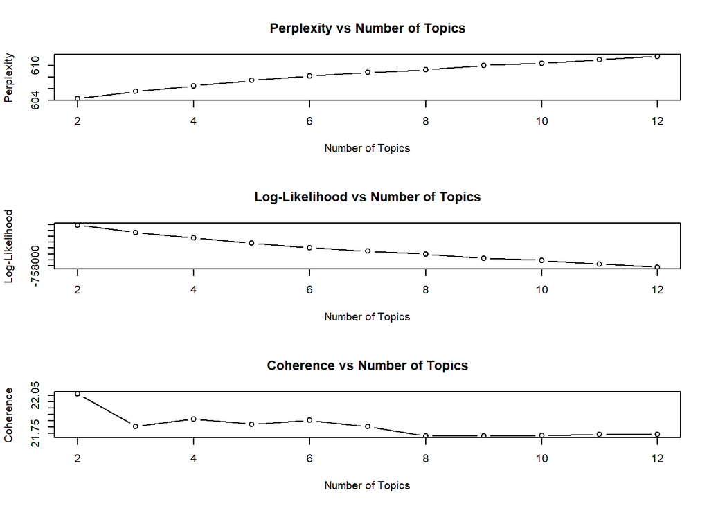

```r
# Tranpose term-document matrix
dtm <- t(filtered_tdm_matrix)

# Define function to compute coherence
compute_coherence <- function(lda_model, dtm, top_n = 10) {
  topics <- tidy(lda_model, matrix = "beta")
  top_terms <- topics %>%
    group_by(topic) %>%
    top_n(top_n, beta) %>%
    ungroup() %>%
    arrange(topic, -beta)


  term_vectors <- split(top_terms$term, top_terms$topic)

  coherence <- sapply(term_vectors, function(term_vector) {
    term_pairs <- combn(term_vector, 2, simplify = FALSE)
    pair_scores <- sapply(term_pairs, function(pair) {
      pair_dtm <- dtm[, pair]
      doc_freq <- rowSums(pair_dtm > 0)
      min_freq <- min(doc_freq)
      joint_freq <- sum(doc_freq == 2)
      log((joint_freq + 1) / (min_freq + 1e-8))

    })
    mean(pair_scores)
  })

  mean(coherence)
}

# Define the range of k values to test
k_values <- seq(2, 12, by = 1)

# Initialize vectors to store the perplexity, log-likelihood, and coherence for each k
perplexities <- numeric(length(k_values))
log_likelihoods <- numeric(length(k_values))
coherences <- numeric(length(k_values))

# Loop over k values
for (i in seq_along(k_values)) {
  k <- k_values[i]

  # Fit the LDA model
  lda_model <- LDA(dtm, k = k, control=list(seed=1))

  # Compute and store the perplexity, log-likelihood, and coherence
  perplexities[i] <- perplexity(lda_model)
  log_likelihoods[i] <- logLik(lda_model)
  coherences[i] <- compute_coherence(lda_model, dtm)
}

# Plot the perplexity, log-likelihood, and coherence against k
par(mfrow = c(3, 1)) # Create a 3x1 sub plot

# Plot the perplexity against k
plot(k_values, perplexities, type = "b", main = "Perplexity vs Number of Topics", xlab = "Number of Topics", ylab = "Perplexity")

# Plot the log-likelihood against k
plot(k_values, log_likelihoods, type = "b", main = "Log-Likelihood vs Number of Topics", xlab = "Number of Topics", ylab = "Log-Likelihood")

# Plot the coherence against k
plot(k_values, coherences, type = "b", main = "Coherence vs Number of Topics", xlab = "Number of Topics", ylab = "Coherence")
```

While perplexity assesses how effectively a probability model predicts a sample, log-likelihood measures the likelihood of observing the data in the model, and coherence evaluates the semantic similarity of high-scoring words within each topic.

#### Initialize LDA

```r
lda_model <- LDA(dtm, k=8, control=list(seed=123))
```

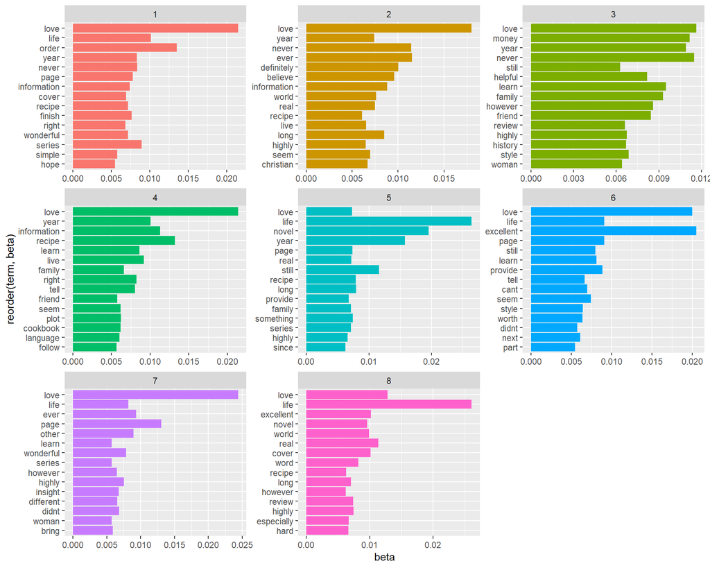

```r
# Extract top terms associated with each topic into a tidy data frame format
topics <- tidy(lda_model, matrix = "beta") # Extract the beta matrix (topic-term probabilities)

# Sort and select the top 15 terms for each topic based on their topic-term probabilities
top_terms <- topics %>%
  group_by(topic) %>%
  top_n(15, beta) %>%
  ungroup() %>%
  arrange(topic, -beta)

# Plot topics
top_terms %>%
  ggplot(aes(x =reorder(term, beta), y = beta, fill = factor(topic))) +
  geom_col(show.legend = FALSE) +
  facet_wrap(~ topic, scales = "free") +
  coord_flip()
```

Based on the terms associated with each topic in the model and the selected genres, we can infer the following:

**Topic 1: Life and Love in Fiction & Biography:** While most words are general and could apply to various genres, terms like *life*, *love*, and *hope* may lean towards genres like **Fiction** or **Biography & Autobiography**. Additionally, words like *information*, *page*, and *series* could suggest a connection to **Computers**.

**Topic 2: Christian Living & Fiction:** This topic contains words like *christian*, *believe*, and *live*, indicating an association with the **Religion** genre. Terms such as *love* and *ever* might also imply a link to **Fiction**, suggesting religious-themed fiction.

**Topic 3: History, Business & Health Insights:** Dominant words like *money*, *history*, *year*, *family*, and *learn* may relate to **Business & Economics** and **History**, or possibly **Health & Fitness** due to terms like *style* and *woman*. This suggests a mix of content related to history, business, lifestyle, and women’s health.

**Topic 4: Culinary Delights & Family Connections:** Words like *recipe*, *family*, and *cookbook* primarily associate with **Cooking** and culinary topics. Additionally, terms like *friend*, *love*, and *live* may indicate a connection to **Family & Relationships**.

**Topic 5: Fictional Narratives & Life Reflections:** Terms such as *novel*, *love*, *life*, and *series* potentially link to ***Fiction** or **Biography & Autobiography**, indicating a focus on fictional narratives and reflections on life experiences.

**Topic 6: Learning & Life Lessons:** With terms like *excellent*, *provide*, *life*, and *learn*, this topic could fit into genres like **Fiction** or **Biography & Autobiography**, suggesting discussions about learning and life’s lessons.

**Topic 7: Inspirations and Wonderful Insights:** Words like *wonderful*, *highly*, and *insight* could associate with genres like **Fiction** or **Biography & Autobiography**, indicating discussions about amazing insights and inspirations.

**Topic 8: Fictional Worlds & Cover Stories:** With words like *novel*, *cover*, and *life*, this topic may relate to the **Fiction** genre, suggesting discussions about fictional worlds and cover stories.

Overall, reasonable coherence is observed in our topics. However, as LDA is a probabilistic model assuming each document (in this case, a book) is a mixture of a certain number of topics, and each word in the document is attributable to one of the document’s topics, some degree of overlap between terms and associated genres is expected. LDA does not create mutually exclusive topics but rather identifies patterns and structures within data to understand underlying themes. Overlaps between topics can be part of these patterns and structures.

Next, we will further analyze the results of the topic model.

#### LDA Model Analysis

```r
# Get the document-topic probabilities
gamma <- tidy(lda_model, matrix = "gamma")

# Iterate through each unique topic and retrieve document’s content
for (topic in unique(gamma$topic)) {
  cat(paste("Topic", topic, "\n"))
  top_docs <- gamma %>%
    filter(topic == !!topic) %>%
    top_n(5, gamma) %>% # Select the top 5 documents most associated with the topic
    pull(document)
  for (doc in top_docs) {
    cat(paste("Document", doc, "\n"))
    cat(as.character(corpus[[doc]]$content), "\n\n")
  }
}
```

```
## Topic 1
## Document 4082
## im fan amazon order booksi believe good service julia childprompted order biography julia child write noel riley fitch also order amazon
##
## Document 5809
## careful want order product amazon existence although offer week place order march two month agoand never arrive finally amazon cancel order can
##
## Document 5981
## order amazoncom good choice make didnt even chance wonder order almost ship moment submit order great service perfect condition
##
## Document 7365
## recommend clock magazine describe make medieval astronomical clock england must excellent order jan yet arrive february evidently great demand short supply amazon invite write review apparently know still arrive finally order elsewhere deliver within week can confirm excellent though reuires good…
##
## Document 8131
## want order copy amazon preview support vendor take plunge expect something go wrong like wrong new late delivery surprise get exactly order receive day two early expect great job amazon special thank treasure christian book deliver perfect productill shop amazon
##
## Topic 2
## Document 267
## love begining end really easy read great illustration help understand point make many time christian do question believe just believe bc author walk come believe make think allow relax bc easy understand
##
## Document 3272
## let just say buy week ago siked page turner think consider star receive definitely feel story line ms cheek work seem though give information wasnt necessary lil information instance jarrin come year long time marry happen thats finshed question
##
## Document 5159
## although contain great deal useful information fairly accurately portray spectrum christian belief instead imply true christian believe bible literally true inerrant also take position true christianity compatible belief evolution just two example numerous statement position many christian find t…
##
## Document 5371
## idea someone share christ latterday saint nothing show ignorance author latterday saint know christ love christ worship christ believe grace christ sacrifice socalled mormon fact christian
##
## Document 7769
## mystery jesus christ great textbook assist study truth christ save action bring forth misunderstanding person christ clarify use writing father church variety theologian youve ever wonder jesus perfect god perfect man author answer write clear straightforward topic course worthwhile
##
## Topic 3
## Document 2257
## great combination research theory appliction suitable classroom text guidebook manager virtual team resource research mix write style section devote specific issue helpful give expand audience previous knowledge team management issue connect virtual meet practice make useful
##
## Document 3124
## book go back forth vbnet cnetand refer old asp never use old aspbasically pay money think get aspnet vbnetrally feel like waste money happy purchasethis may good people know vbnet cnetotherwise do waste money
##
## Document 4195
```

[output cut: 72 more lines]

```
## Topic 8
## Document 2392
## cosmic world believe philosophy karma fascinate read author take reader another world alltogether life different dimension reader realize almost certainly another world another way life life death life continuum fascinate grip account eastern philosophy
##
## Document 3401
## excellent resource begin sustain womens ministry local church clear explanation one need church think scripturally work womens ministry church always appreciate write word god final authority thing ministry begin local church highly recommend
##
## Document 3532
## adobe photoshop c oneonone oneonone innovation train field complete course addition suitable level can befit course regardless knowledge level photoshop course full real live example illustration live dvd course really call stepbystep education think amazon market
##
## Document 5362
## hour want live freehold freehold usa intend libertarian society fact old society spawn new society decline typical fact old society attack new society also typical factthe character good develop great
##
## Document 7395
## sadly take engish twice year retake course accident hospitalize first english course honor class 2 accellerated course first class understand 2 course class good idea part find bore without mean main comment shouldnt teach accellerated level think alright
```

Next, we will implement a LDAvis visualization on our topic model.

#### LDAvis Visualization

```r
lda_vis_data <- createJSON(phi = posterior(lda_model)$terms, theta = posterior(lda_model)$topics,
                          doc.length = rowSums(as.matrix(dtm)),vocab = colnames(as.matrix(dtm)),
                          term.frequency = colSums(as.matrix(dtm)))

#library(servr)
serVis(lda_vis_data)
#servr::daemon_stop(1)
```

LDAvis is a valuable tool for interpreting the output of an LDA model.

# EXPLORATORY DATA ANALYSIS

In this section, we will carry out a range of exploratory data techniques on our features to draw meaningful insights from the data.

```r
da <- df_main # Copy dataframe
# Select Columns
da <- da %>%
  select(c("id", "Title", "Book_Price", "Rating", "Review_title", "Review_text",
           "Found_helpful_ratio", "Publisher", "First_author", "Genre"))
```

First, let’s explore key statistics about our dataset including, how many books we have in our dataset, average review title and text lengths, average price of the books, average helpfulness ratio, and the most expensive book.

```r
# Check number of books reviewed
num_unique_books <- da %>%
  distinct(Title) %>%
  nrow()

print(num_unique_books) # Print number of books in the dataset
```

```
## [1] 17939
```

```r
# Get most expensive book
da[which.max(da$Book_Price), c("Title", "First_author", "Book_Price", "Rating", "Publisher")]
```

```
## # A tibble: 1 × 5
##   Title                                 First_author Book_Price Rating Publisher
##   <chr>                                 <chr>             <dbl>  <int> <chr>
## 1 Visual Genetics Plus: Tutorial and L… Alan W. Day         995      3 Jones & …
```

```r
# Function to count words
count_words <- function(text) {
  if (is.character(text) && !is.na(text)) {
    words <- strsplit(text, "\\s+")[[1]]
    return(length(words))
  } else {
    return(NA)
  }
}

# Apply function to calculate average length of review text
avg_review_text <- da %>%
  mutate(word_count = sapply(Review_text, count_words)) %>%
  group_by(Title) %>%
  summarise(avg_word_count = round(mean(word_count, na.rm = TRUE)), .groups = "drop")

# Apply function to calculate average length of review titles
avg_review_title <- da %>%
  mutate(word_count = sapply(Review_title, count_words)) %>%
  group_by(Title) %>%
  summarise(avg_word_count = round(mean(word_count, na.rm = TRUE)), .groups = "drop")

# Calculate the average helpfulness ratio
avg_helpfulness <- da %>%
  group_by(Title) %>%
  summarise(avg_helpfulness_ratio = mean(Found_helpful_ratio, na.rm = TRUE))

# Calculate the average price of books
avg_price <- da %>%
  group_by(Title) %>%
  summarise(avg_book_price = mean(Book_Price, na.rm = TRUE))
```

#### Exploratory Stats Visualization

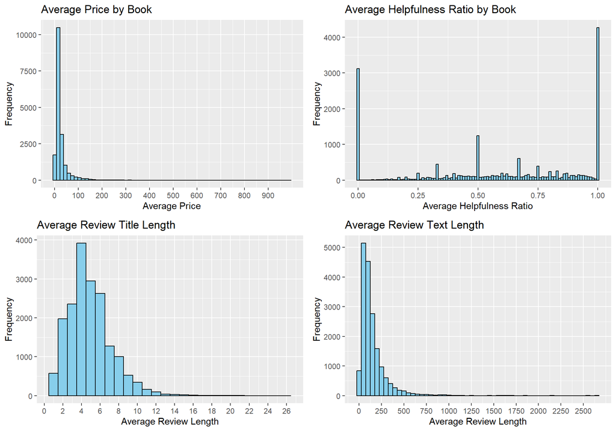

```r
# Create a histogram of average book price
price <- ggplot(avg_price, aes(x = avg_book_price)) +
  geom_histogram(binwidth = 15, fill = "skyblue", color = "black") +
  labs(title = "Average Price by Book",
       x = "Average Price",
       y = "Frequency")+
  scale_x_continuous(breaks = seq(0, max(avg_price$avg_book_price), by = 100))


# Create a histogram of average helpfulness ratio
helpfulness <- ggplot(avg_helpfulness, aes(x = avg_helpfulness_ratio)) +
  geom_histogram(binwidth = 0.01, fill = "skyblue", color = "black") +
  labs(title = "Average Helpfulness Ratio by Book",
       x = "Average Helpfulness Ratio",
       y = "Frequency")

# Plot distribution of average review titles
title <- ggplot(avg_review_title, aes(x = avg_word_count)) +
  geom_histogram(binwidth = 1, fill = "skyblue", color = "black") +
  labs(title = "Average Review Title Length",
       x = "Average Review Length",
       y = "Frequency") +
  scale_x_continuous(breaks = seq(0, max(avg_review_title$avg_word_count), by = 2))

# Plot distribution of average review text
text <- ggplot(avg_review_text, aes(x = avg_word_count)) +
  geom_histogram(binwidth = 50, fill = "skyblue", color = "black") +
  labs(title = "Average Review Text Length",
       x = "Average Review Length",
       y = "Frequency") +
  scale_x_continuous(breaks = seq(0, max(avg_review_text$avg_word_count), by = 250))

# Arrange plots in a 2x2 grid
grid.arrange(price, helpfulness, title, text, nrow = 2, ncol = 2)
```

We have a total of 59,296 reviews in our dataset, which correspond to 17,939 books.

From the plots, it’s evident that the average price of most books falls between $10 and $20, with only a few books priced above $150.

Review titles tend to be succinct, averaging between 3 to 6 words. In contrast, review texts are more detailed, with an average length ranging between 50 and 200 words. On average, readers found the reviews helpful.

The most expensive book in our dataset is **Visual Genetics Plus: Tutorial and Lab Simulations, Site License** authored by Alan W. Day, published by Jones & Bartlett Publishers, and priced at $995.

Next, we will explore the distribution of books to identify the most popular books by ratings and reviews, as well as the least popular ones in the dataset.

#### Distribution of Books

```r
# Calculate weighted score based on ratings and number of reviews
book_counts <- da %>%
  group_by(Title, First_author, Genre) %>%
  summarise(avg_rating = mean(Rating),
            total_reviews = n(), .groups = "drop") %>%
  arrange(desc(total_reviews), desc(avg_rating))

# Get book counts and corresponding genres with the weighted scores
top_books <- head(book_counts[order(-book_counts$avg_rating * book_counts$total_reviews), ], 5)
least_books <- tail(book_counts[order(-book_counts$avg_rating * book_counts$total_reviews), ], 5)

# Print best books and worst books
print(top_books)
```

```
## # A tibble: 5 × 5
##   Title                              First_author Genre avg_rating total_reviews
##   <chr>                              <chr>        <chr>      <dbl>         <int>
## 1 Great Expectations                 Charles Dic… Fict…       4.22           263
## 2 Eldest (Inheritance, Book 2)       Christopher… Juve…       3.68           276
## 3 The Five Love Languages: The Secr… Gary Chapman Fami…       4.70           201
## 4 Good to Great                      Jim Collins  Busi…       4.26           203
## 5 Hannibal                           Thomas Harr… Fict…       3.18           258
```

```r
print(least_books)
```

```
## # A tibble: 5 × 5
##   Title                              First_author Genre avg_rating total_reviews
##   <chr>                              <chr>        <chr>      <dbl>         <int>
## 1 Women in Early Medieval Europe, 4… Lisa M. Bit… Hist…          1             1
## 2 Writing Your First Play            Roger Hall   Perf…          1             1
## 3 You Called Me What?: The Sun Guid… John Perry   Biog…          1             1
## 4 You Might Be a Turkey Hunter If... John Trout   Spor…          1             1
## 5 Your 24/7 Online Job Search Guide  Lamont Wood  Busi…          1             1
```

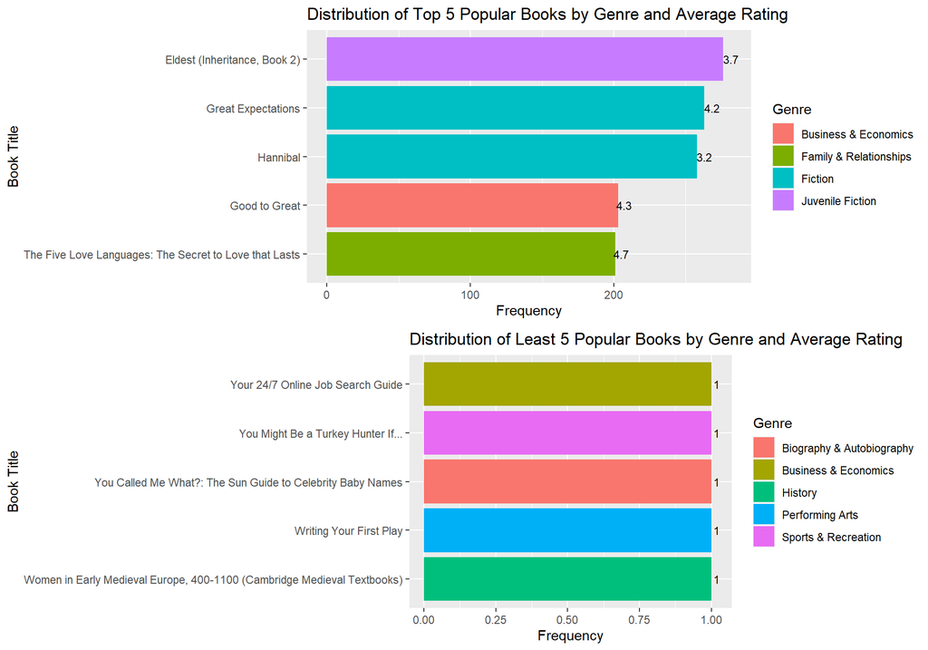

```r
# Create the plot for top 5 popular books
book_1 <- ggplot(top_books, aes(x = reorder(Title, total_reviews), y = total_reviews, fill = Genre)) +
  geom_bar(stat = "identity") +
  geom_text(aes(label = round(avg_rating, 1)), position = position_stack(vjust = 1.02),
            color = "black", size = 3) +
  labs(title = "Distribution of Top 5 Popular Books by Genre and Average Rating",
       x = "Book Title", y = "Frequency", fill = "Genre") +
  scale_fill_discrete(name = "Genre") +
  coord_flip()

# Create the plot for least 5 popular books
book_2 <- ggplot(least_books, aes(x = reorder(Title, total_reviews), y = total_reviews, fill = Genre)) +
  geom_bar(stat = "identity") +
  geom_text(aes(label = round(avg_rating, 1)), position = position_stack(vjust = 1.02),
            color = "black", size = 3) +
  labs(title = "Distribution of Least 5 Popular Books by Genre and Average Rating",
       x = "Book Title", y = "Frequency", fill = "Genre") +
  scale_fill_discrete(name = "Genre") +
  coord_flip()

# Arrange plots in a 2x1 grid
grid.arrange(book_1, book_2, nrow = 2)
```

Since most books have multiple ratings, we calculated weighted scores based on average ratings and the number of reviews for each book.

From the plots, the most popular book is *Eldest (Inheritance, Book 2)* with 276 reviews and an average rating of 3.68, closely followed by *Great Expectations* and *Hannibal* with average ratings of 4.22 and 3.18, respectively.

However, based on the weighted scores of ratings and reviews, the best book is *Great Expectations* by Charles Dickens, followed by *Eldest (Inheritance, Book 2)* by Christopher Paolini.

The 5 least popular books mostly have a rating of 1 from one review each. The genres include Performing Arts, History, Biography & Autobiography, Business & Economics, and Sports & Recreation. They include books like *Writing Your First Play*, *Women in Early Medieval Europe, 400-1100 (Cambridge Medieval Textbooks)*, etc. The least popular is *Your 24/7 Online Job Search Guide* by Lamont Wood.

Next, we will explore the distribution of genres.

#### Distribution of Genres

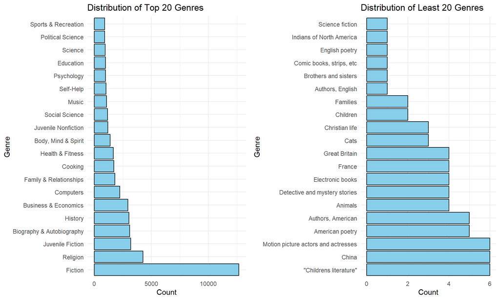

```r
# Filter most popular and least popular genres
genre_counts <- data.frame(table(da$Genre)) %>% arrange(desc(Freq))

top_genres = head(genre_counts, 20)
least_genres = tail(genre_counts, 20)

# Plot the distribution of top 20 genres
p1 <- ggplot(top_genres, aes(x = reorder(Var1, -Freq), y=Freq)) +
  geom_bar(stat="identity", fill = "skyblue", color = "black") +
  coord_flip() +
  labs(title = "Distribution of Top 20 Genres",
       x = "Genre",
       y = "Count") +
  theme_minimal()

# Plot the distribution of least 20 genres
p2 <- ggplot(least_genres, aes(x = reorder(Var1, -Freq), y=Freq)) +
  geom_bar(stat="identity", fill = "skyblue", color = "black") +
  coord_flip() +
  labs(title = "Distribution of Least 20 Genres",
       x = "Genre",
       y = "Count") +
  theme_minimal()

# Arrange plots in a 1x2 grid
grid.arrange(p1, p2, ncol = 2)
```

The most popular genre is *Fiction*, with over 12,000 book reviews, followed by *Religion*, *Juvenile Fiction*, and *Biography & Autobiography*.

Conversely, the least popular genres include *Science Fiction*, *English Poetry*, *Indians of North America*, and *Comic books, strips, etc*, each with just one review.

Next, we will explore the genres and authors by ratings. Given the variability in the number of reviews per book, we will calculate the average ratings for each genre and author based on the number of reviews.

#### Distribution of Authors and Genres by ratings

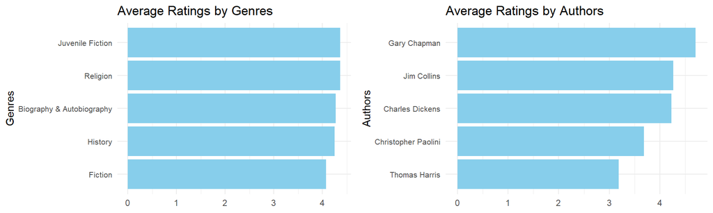

```r
# Calculate average ratings for each genre
genre_ratings <- da %>%
  group_by(Genre) %>%
  summarize(num_reviews = n(), avg_rating = mean(Rating, na.rm = TRUE)) %>%
  arrange(desc(num_reviews))

# Calculate average ratings for each author
author_ratings <- da %>%
  group_by(First_author) %>%
  summarise(avg_rating = mean(Rating, na.rm = TRUE), total_reviews = n()) %>%
  arrange(desc(total_reviews), desc(avg_rating))


# Plot the distribution of top 10 genres based on ratings
genres = ggplot(head(genre_ratings, 5), aes(x = reorder(Genre, avg_rating), y = avg_rating)) +
  geom_bar(stat = "identity", fill = "skyblue") +
  coord_flip() +
  labs(title = "Average Ratings by Genres",
       x = "Genres",
       y = "Average Rating") +
  theme_minimal() +
  theme(axis.text.y = element_text(size = 8),
        axis.title.x = element_blank())


# Plot the distribution of top 10 authors based on ratings
authors = ggplot(head(author_ratings, 5), aes(x = reorder(First_author, avg_rating), y = avg_rating)) +
  geom_bar(stat = "identity", fill = "skyblue") +
  coord_flip() +
  labs(title = "Average Ratings by Authors",
       x = "Authors",
       y = "Average Rating") +
  theme_minimal() +
  theme(axis.text.y = element_text(size = 8),
        axis.title.x = element_blank())

# Arrange plots in a 1x2 grid
grid.arrange(genres, authors, ncol = 2)
```

While Fiction is the most popular genre reviewed, Juvenile Fiction has the highest average ratings per book review, followed closely by Religion and Biography & Autobiography.

Next, we will examine the distributions of ratings and top publishers.

#### Distribution of ratings and helpfulness ratio

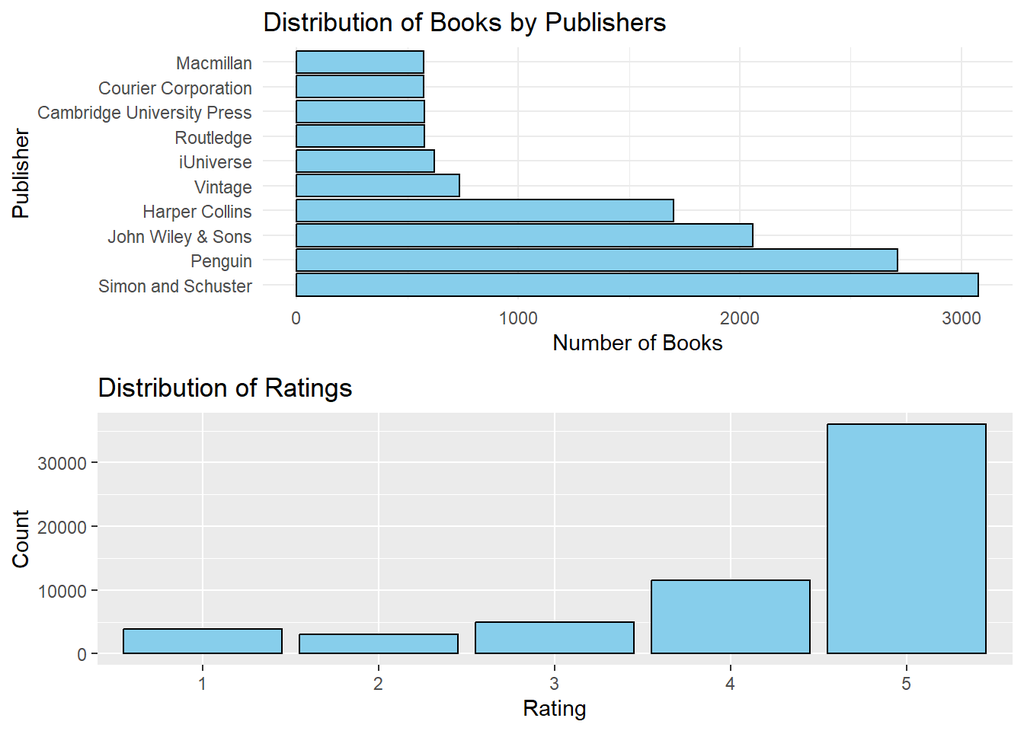

```r
# Group the data by Publisher and count the number of books for each publisher
publishers <- data.frame(table(da$Publisher)) %>% arrange(desc(Freq))

# Create a bar plot to visualize the distribution of books by top 10 publishers
publish <- ggplot(data = head(publishers, 10), aes(x = reorder(Var1, -Freq), y = Freq)) +
  geom_bar(stat="identity", fill = "skyblue", color = "black") +
  theme_minimal() +
  labs(title = "Distribution of Books by Publishers", x = "Publisher", y = "Number of Books")+
  coord_flip()

# Bar chart of ratings
bar_ratings <- ggplot(df, aes(x = as.factor(Rating))) +
  geom_bar(fill = "skyblue", color = "black") +
  labs(title = "Distribution of Ratings", x = "Rating", y = "Count") +
  scale_x_discrete(labels = c("1", "2", "3", "4", "5"))


# Arrange plots in a 2x1 grid
grid.arrange(publish, bar_ratings, nrow = 2)
```

```r
# Calculate the percentage of ratings that are 5
rate_5 <- mean(da$Rating == 5) * 100

# Calculate the percentage of helpfulness ratio that are 0 and 1
perc_0 <- mean(da$Found_helpful_ratio == 0) * 100
perc_1 <- mean(da$Found_helpful_ratio == 1) * 100

# Print the results
cat("Helpfulness ratios that are either 0 or 1:", perc_0 + perc_1, "%\n")
```

```
## Helpfulness ratios that are either 0 or 1: 62.86765 %
```

```r
cat("Ratings that are 5:", rate_5, "%\n")
```

```
## Ratings that are 5: 60.80005 %
```

From the plot, we can see that the most popular publisher is Simon and Schuster, with over 3000 publications, followed by Penguin and John Wiley & Sons, each with over 2000 published books respectively.

Moreover, it’s notable that the majority of books received good ratings, with over 60% of them rated `5`. Additionally, close to 63% of readers either found the reviews and ratings extremely helpful or not helpful at all.

Next, we will investigate if the number of reviews influences the price of a book and if the length of the review text influences the helpfulness ratio.

#### Correlation analysis of reviews with price and helpfulness ratio

```r
# We will utilize the count_words function we defined earlier
count_words
```

```
## function(text) {
##   if (is.character(text) && !is.na(text)) {
##     words <- strsplit(text, "\\s+")[[1]]
##     return(length(words))
##   } else {
##     return(NA)
##   }
## }
## <bytecode: 0x000002319ea6ff08>
```

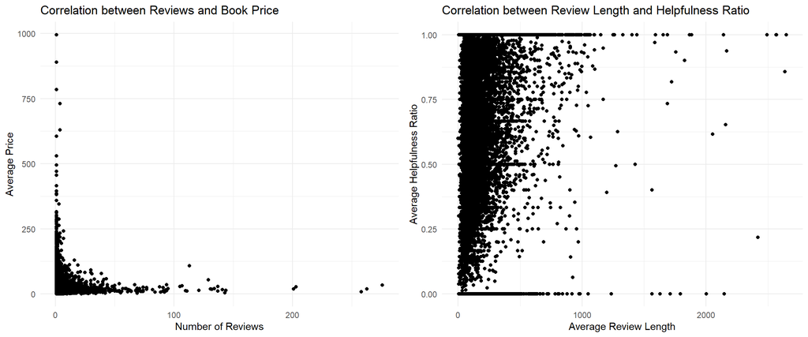

```r
# Apply function to calculate the length of each review & select relevant features
corr_reviews <- da %>%
  mutate(Review_length = sapply(Review_text, count_words)) %>%
  group_by(Title) %>%
  summarise(num_reviews = n(),
            avg_review_length = round(mean(Review_length, na.rm = TRUE)),
            avg_found_helpful_ratio = mean(Found_helpful_ratio, na.rm = TRUE),
            avg_price = round(mean(Book_Price, na.rm = TRUE)),
            .groups = "drop")


# Create a scatter plot of reviews by price
corr_review_price <- ggplot(corr_reviews, aes(x = num_reviews, y = avg_price)) +
  geom_point() +
  labs(x = "Number of Reviews", y = "Average Price") +
  ggtitle("Correlation between Reviews and Book Price") +
  theme_minimal()

# Create a scatter plot of review length by helpfulness ratio
corr_review_help <- ggplot(corr_reviews, aes(x = avg_review_length, y = avg_found_helpful_ratio)) +
  geom_point() +
  labs(x = "Average Review Length", y = "Average Helpfulness Ratio") +
  ggtitle("Correlation between Review Length and Helpfulness Ratio") +
  theme_minimal()

# Arrange plots in a 1x2 grid
grid.arrange(corr_review_price, corr_review_help, ncol = 2)
```

```r
# Compute the correlation between tyhe features
corr_rhelp <- cor(corr_reviews$avg_review_length, corr_reviews$avg_found_helpful_ratio)
corr_rprice <- cor(corr_reviews$num_reviews, corr_reviews$avg_price)

cat("Correlation coefficient of average review length and average helpfulness ratio:", corr_rhelp, "%\n")
```

```
## Correlation coefficient of average review length and average helpfulness ratio: 0.1999204 %
```

```r
cat("Correlation coefficient of number of reviews and average price:", corr_rprice, "%\n")
```

```
## Correlation coefficient of number of reviews and average price: -0.05547958 %
```

Next, we will examine the relationship between the ratings and the sentiment scores from our sentiment analysis.

#### Distribution of sentiment scores by ratings

```r
# Preview sentiment data
head(df_sentiment, 2)
```

```
## # A tibble: 2 × 9
##      id Title     Rating Review_title Review_text bing_sentiment afinn_sentiment
##   <int> <chr>      <int> <chr>        <chr>                <int>           <dbl>
## 1     1 In Six D…      4 Solid testi… Working fr…              1               6
## 2     2 Lord Jim       5 &quot;You d… A terrific…              1               4
## # ℹ 2 more variables: bing_sentiment_category <chr>,
## #   afinn_sentiment_category <chr>
```

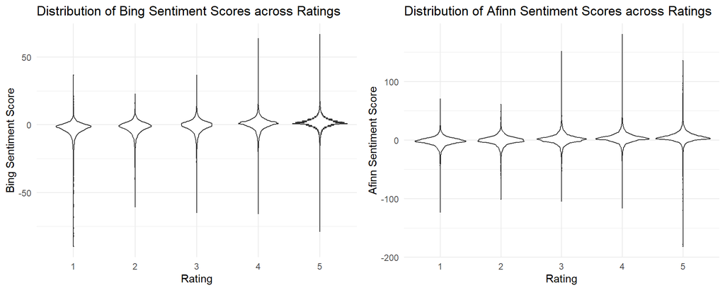

```r
# Create violin plot of ratings and bing sentiment scores
bing_violin <- ggplot(df_sentiment, aes(x = factor(Rating), y = bing_sentiment)) +
  geom_violin() +
  labs(x = "Rating", y = "Bing Sentiment Score") +
  ggtitle("Distribution of Bing Sentiment Scores across Ratings") +
  theme_minimal()

# Create violin plot of ratings and afinn sentiment scores
afinn_violin <- ggplot(df_sentiment, aes(x = factor(Rating), y = afinn_sentiment)) +
  geom_violin() +
  labs(x = "Rating", y = "Afinn Sentiment Score") +
  ggtitle("Distribution of Afinn Sentiment Scores across Ratings") +
  theme_minimal()

# Arrange plots in a 1x2 grid
grid.arrange(bing_violin, afinn_violin, ncol = 2)
```

Overall, there is an observed relationship between the rating and sentiment scores in both plots. However, this relationship is not clearly defined, indicating that a higher rating does not necessarily correspond to a higher sentiment score, and vice versa. This lack of clear correlation could be attributed to the nature of the reviews.

# CONCLUSION

In this project, we delved into a comprehensive analysis of Amazon book reviews utilizing various analytical techniques in R. Our exploration aimed to extract meaningful insights into reader sentiments, preferences, and trends hidden within the reviews. Through text mining, sentiment analysis, topic modeling, and exploratory data analysis, we uncovered valuable findings that shed light on the dynamics of the reviews. Our dataset contained 17,939 books which have a total of 59,296 reviews. The key findings from our analysis include -

#### Key Findings

- **Text Mining:** Through tokenization and preprocessing, we identified prominent themes such as “book,” “read,” and related terms, indicating a strong focus on literature and reading habits among reviewers.
- **Sentiment Analysis:** Utilizing Bing and AFINN sentiment lexicons, we found a prevalence of positive sentiments across reviews. However, variations existed between the two lexicons, suggesting nuanced interpretations of sentiment.
- **Topic Modelling:** Employing Latent Dirichlet Allocation (LDA), we identified eight distinct topics, ranging from fictional narratives to culinary delights, providing insights into the diverse content covered in the reviews.
- **Exploratory Data Analysis:** While “Fiction” emerged as the most reviewed genre, deeper analysis revealed variations in reader preferences across genres. Genres such as “Juvenile Fiction” and “Religion” exhibited higher average ratings per review, indicating potential areas of interest for targeted marketing efforts.

Certain authors, including Gary Chapman, Jim Collins, and Charles Dickens, consistently garnered high average ratings, underscoring the importance of author reputation in driving reader satisfaction and engagement.

While a correlation between ratings and sentiment scores was observed, the relationship was not definitive. Higher ratings did not consistently correspond to higher sentiment scores, indicating the multifaceted nature of reader perceptions and preferences.

The price of the books were not influenced by the number of reviews, and more readers found the reviews very helpful than not.

#### Recommendations for Future Work

- Exploration of advanced sentiment analysis techniques, such as aspect-based sentiment analysis, to dissect sentiments based on specific aspects of the books (e.g., plot, characters, writing style).
- Conducting genre-specific analyses to uncover unique patterns and preferences within each genre, providing targeted insights for publishers and authors.
- Augmentation of the analysis with external datasets, such as sales data or author backgrounds, to enrich understanding and predictions of book success factors.
- Development of predictive models to forecast book ratings based on various features, enabling proactive decision-making for publishers and authors.

#### Limitations

- Data Bias: Due to limited computational resource, the analysis was restricted to the selection bias in reviews and genre categorization.
- Sentiment Lexicons: The reliance on pre-existing sentiment lexicons might have potentially introduce limitations in capturing the complexity of nuanced sentiments expressed in reviews.
- Data Quality: Quality issues such as incomplete or inaccurate reviews could have impacted the reliability of the analysis outcomes.
- Feature Limitations: The dataset’s limited features might have constrained the depth of analysis, necessitating further data enrichment for comprehensive insights.
- Topic Interpretation: While topic modeling revealed distinct themes, the interpretation of topics is subjective and might vary based on individual perspectives.